# Gap-Based Credit Spread Research

**Hypothesis:** After overnight gaps ≥ 1 ATR in equity index ETFs, selling short-dated credit spreads anchored at the previous day's close may yield positive expectancy due to mean reversion or limited immediate trend continuation.

**Data:** yfinance 5m intraday (~60 days) + daily OHLCV (10+ years) + VIX. **Assets:** SPY, QQQ, IWM (primary); ES=F, NQ=F (secondary — roll gap caveat applies).

**Two-layer design:**

- **Layer 1 — Price Path:** pure price analysis, no synthetic assumptions.
- **Layer 2 — Credit Spread [Synthetic]:** Black-Scholes + VIX/100 as IV proxy. Labeled throughout.

```python
import sys
sys.path.insert(0, ".")

import warnings
warnings.filterwarnings("ignore")

import pandas as pd
import numpy as np
import matplotlib.pyplot as plt
import matplotlib.gridspec as gridspec
from pathlib import Path

from lib.data import fetch, split_session
from lib.events import detect_events
from lib.path import analyze_paths, label_vix_regime
from lib.spreads import simulate_exits, compute_metrics

plt.style.use("seaborn-v0_8-whitegrid")
plt.rcParams.update({"figure.dpi": 120, "font.size": 11})
CHARTS_DIR = Path("charts")
CHARTS_DIR.mkdir(exist_ok=True)
```

```python
# ── Configuration (edit here to re-run with different parameters) ──────────
TICKERS_PRIMARY   = ["SPY", "QQQ", "IWM"]
TICKERS_SECONDARY = ["ES=F", "NQ=F"]
ALL_TICKERS       = TICKERS_PRIMARY + TICKERS_SECONDARY
VIX_TICKER        = "^VIX"

ATR_PERIOD        = 14
GAP_THRESHOLD     = 1.0      # minimum |gap| in ATR units
SPREAD_WIDTH_ATR  = 0.5      # wing width as fraction of ATR
DTE               = 1        # days to expiration for spread pricing
RISK_FREE_RATE    = 0.05

PROFIT_TARGETS    = [0.25, 0.50, 0.75]
STOP_MULTIPLES    = [1, 2, 3]
ENTRY_TIMES       = ["09:30", "09:45", "10:00", "10:30"]
VIX_REGIMES       = {"low": (0, 15), "mid": (15, 25), "high": (25, 999)}

COLORS_DIR = {"gap_up": "#2ca02c", "gap_down": "#d62728"}
COLORS_REGIME = {"low": "#1f77b4", "mid": "#ff7f0e", "high": "#d62728"}
```

## 1. Data

Loading daily and 5m intraday data. First run fetches from yfinance and writes parquet cache; subsequent runs load from cache instantly. Set `force_refresh=True` to re-fetch.

Note: Yahoo Finance limits 5m data to ~60 days. Daily data goes back to 2013.

```python
print("Loading daily data...")
daily   = {t: fetch(t, "1d") for t in ALL_TICKERS}
vix_daily = fetch(VIX_TICKER, "1d")

print("Loading 5m intraday data (may take a minute on first run)...")
intraday = {t: fetch(t, "5m") for t in ALL_TICKERS}
print("Done.")

# Split into pre-market and session bars
premarkets = {}
sessions   = {}
for t in ALL_TICKERS:
    pm, sess = split_session(intraday[t])
    premarkets[t] = pm
    sessions[t]   = sess

print("\nSample counts:")
for t in ALL_TICKERS:
    print(f"  {t}: {len(daily[t])} daily bars, "
          f"{len(premarkets[t])} pre-market 5m bars, "
          f"{len(sessions[t])} session 5m bars")
```

```
Loading daily data...
Loading 5m intraday data (may take a minute on first run)...
```

```
Done.

Sample counts:
  SPY: 3386 daily bars, 3764 pre-market 5m bars, 4740 session 5m bars
  QQQ: 3386 daily bars, 3941 pre-market 5m bars, 4740 session 5m bars
  IWM: 3386 daily bars, 3764 pre-market 5m bars, 4740 session 5m bars
  ES=F: 3388 daily bars, 3214 pre-market 5m bars, 3870 session 5m bars
  NQ=F: 3388 daily bars, 3214 pre-market 5m bars, 3871 session 5m bars
```

```python
print("Detecting gap events...")
events_by_ticker = {}
for t in ALL_TICKERS:
    ev = detect_events(
        daily[t], premarkets[t], vix_daily,
        threshold=GAP_THRESHOLD, atr_period=ATR_PERIOD,
    )
    ev["ticker"] = t
    events_by_ticker[t] = ev

all_events = pd.concat(events_by_ticker.values())

summary = all_events.groupby(["ticker", "direction"]).size().unstack(fill_value=0)
print(f"\nTotal gap events: {len(all_events)}")
display(summary)
```

```
Detecting gap events...

Total gap events: 239
```

| direction ticker | gap_down | gap_up |
| --- | --- | --- |
| ES=F | 9 | 7 |
| IWM | 34 | 21 |
| NQ=F | 6 | 5 |
| QQQ | 47 | 31 |
| SPY | 50 | 29 |

## 2. Gap Event Characterization

Before simulating trades, we characterize the events themselves: how large are gaps, how often do they occur in each direction, and how much of the gap is already retracing in pre-market before the 9:30 open.

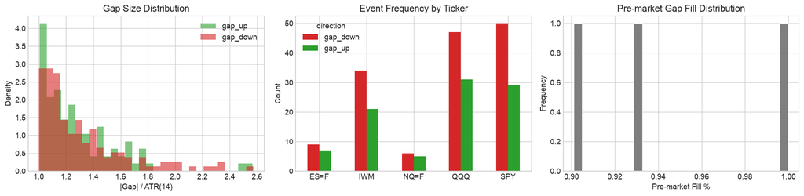

```python
fig, axes = plt.subplots(1, 3, figsize=(16, 4))

# Panel 1: Gap ratio distribution by direction
for direction, color in COLORS_DIR.items():
    subset = all_events[all_events["direction"] == direction]["gap_ratio"].abs()
    axes[0].hist(subset, bins=30, alpha=0.6, color=color, label=direction, density=True)
axes[0].set_xlabel("|Gap| / ATR(14)")
axes[0].set_ylabel("Density")
axes[0].set_title("Gap Size Distribution")
axes[0].legend()

# Panel 2: Direction frequency per ticker
counts = all_events.groupby(["ticker", "direction"]).size().unstack(fill_value=0)
counts.plot(kind="bar", ax=axes[1], color=[COLORS_DIR.get(c, "gray") for c in counts.columns],
            rot=0)
axes[1].set_title("Event Frequency by Ticker")
axes[1].set_xlabel("")
axes[1].set_ylabel("Count")

# Panel 3: Pre-market fill % distribution
all_events["premarket_fill_pct"].dropna().plot(
    kind="hist", bins=25, ax=axes[2], color="#7f7f7f", edgecolor="white"
)
axes[2].set_xlabel("Pre-market Fill %")
axes[2].set_title("Pre-market Gap Fill Distribution")

plt.tight_layout()
plt.savefig(CHARTS_DIR / "01_gap_characterization.png", dpi=150, bbox_inches="tight")
plt.show()
```

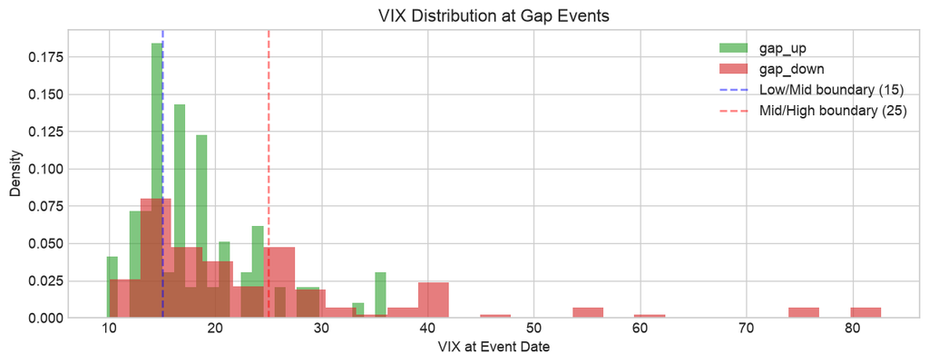

```
Events by VIX regime:
```

| direction regime | gap_down | gap_up |
| --- | --- | --- |
| high | 52 | 10 |
| low | 30 | 36 |
| mid | 64 | 47 |

```python
# VIX distribution at event time
fig, ax = plt.subplots(figsize=(10, 4))
for direction, color in COLORS_DIR.items():
    subset = all_events[all_events["direction"] == direction]["vix_close"].dropna()
    ax.hist(subset, bins=25, alpha=0.6, color=color, label=direction, density=True)
ax.set_xlabel("VIX at Event Date")
ax.set_ylabel("Density")
ax.set_title("VIX Distribution at Gap Events")
ax.axvline(15, color="blue", linestyle="--", alpha=0.5, label="Low/Mid boundary (15)")
ax.axvline(25, color="red", linestyle="--", alpha=0.5, label="Mid/High boundary (25)")
ax.legend()
plt.tight_layout()
plt.savefig(CHARTS_DIR / "02_vix_at_events.png", dpi=150, bbox_inches="tight")
plt.show()

vix_regime_counts = all_events.copy()
vix_regime_counts["regime"] = label_vix_regime(vix_regime_counts["vix_close"].fillna(20))
print("Events by VIX regime:")
display(vix_regime_counts.groupby(["regime", "direction"]).size().unstack(fill_value=0))
```

## 3. Price-Path Analysis — Layer 1

**No synthetic assumptions.** All results derived from 5m price bars only.

We compute gap fill rate, time-to-fill, MAE, and repeat across four entry times (09:30, 09:45, 10:00, 10:30) to find whether waiting improves the edge.

```python
print("Computing price paths (this takes ~1-2 minutes for all tickers)...")
paths_by_ticker = {}
for t in ALL_TICKERS:
    print(f"  {t}...", end=" ", flush=True)
    paths_by_ticker[t] = analyze_paths(
        events_by_ticker[t], sessions[t], entry_times=ENTRY_TIMES
    )
    paths_by_ticker[t]["ticker"] = t
    print(f"{len(paths_by_ticker[t])} rows")

all_paths = pd.concat(paths_by_ticker.values(), ignore_index=True)
all_paths["vix_regime"] = label_vix_regime(all_paths["vix_close"].fillna(20))
print(f"\nTotal path rows: {len(all_paths)}  ({len(all_paths) // len(ENTRY_TIMES)} events × {len(ENTRY_TIMES)} entry times)")
```

```
Computing price paths (this takes ~1-2 minutes for all tickers)...
  SPY...
```

```
4 rows
  QQQ...
```

```
4 rows
  IWM...
```

```
4 rows
  ES=F...
```

```
0 rows
  NQ=F...
```

```
0 rows

Total path rows: 12  (3 events × 4 entry times)
```

### 3a. Gap Fill Rate & Time-to-Fill

[figure not shown]

```
Overall fill rate (open entry): 0.0%
Median time to fill: nan minutes
```

```python
open_paths = all_paths[all_paths["entry_time"] == "09:30"]

fig, axes = plt.subplots(1, 2, figsize=(14, 5))

# Fill rate by ticker and direction
fill_rate = open_paths.groupby(["ticker", "direction"])["gap_filled"].mean().unstack()
fill_rate.plot(kind="bar", ax=axes[0], color=[COLORS_DIR.get(c, "gray") for c in fill_rate.columns], rot=0)
axes[0].set_title("Gap Fill Rate by Ticker (Entry: Open)")
axes[0].set_ylabel("Fill Rate")
axes[0].set_ylim(0, 1)
axes[0].axhline(0.5, color="black", linestyle="--", alpha=0.4, label="50%")
axes[0].legend()

# Time-to-fill distribution (filled events only)
filled = open_paths[open_paths["gap_filled"]]["fill_time"].dropna()
axes[1].hist(filled, bins=30, color="#1f77b4", edgecolor="white")
axes[1].set_xlabel("Minutes from Open to Fill")
axes[1].set_title("Time-to-Fill Distribution (Filled Events Only)")
axes[1].axvline(filled.median(), color="red", linestyle="--", label=f"Median: {filled.median():.0f} min")
axes[1].legend()

plt.tight_layout()
plt.savefig(CHARTS_DIR / "03_fill_rate_time.png", dpi=150, bbox_inches="tight")
plt.show()

print(f"Overall fill rate (open entry): {open_paths['gap_filled'].mean():.1%}")
print(f"Median time to fill: {filled.median():.0f} minutes")
```

### 3b. MAE Distribution

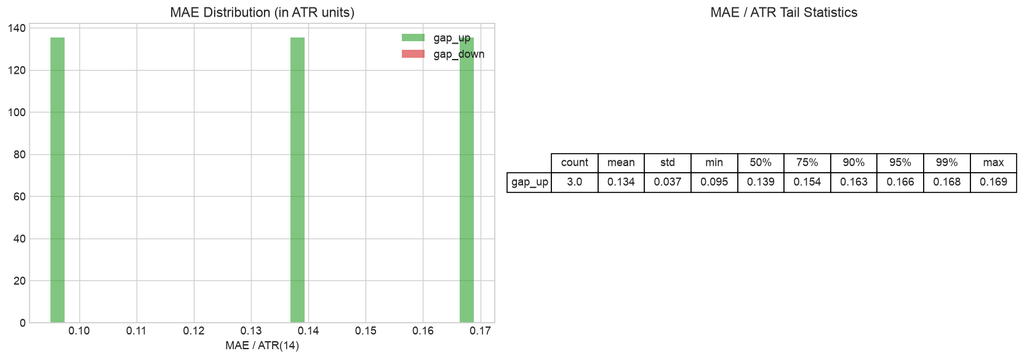

```python
fig, axes = plt.subplots(1, 2, figsize=(14, 5))

for direction, color in COLORS_DIR.items():
    subset = open_paths[open_paths["direction"] == direction]["mae_pct_atr"].dropna()
    axes[0].hist(subset, bins=30, alpha=0.6, color=color, label=direction, density=True)
axes[0].set_xlabel("MAE / ATR(14)")
axes[0].set_title("MAE Distribution (in ATR units)")
axes[0].legend()

# Tail statistics table
tail_stats = open_paths.groupby("direction")["mae_pct_atr"].describe(
    percentiles=[0.50, 0.75, 0.90, 0.95, 0.99]
).round(3)
axes[1].axis("off")
tbl = axes[1].table(
    cellText=tail_stats.values,
    rowLabels=tail_stats.index,
    colLabels=tail_stats.columns,
    loc="center",
    cellLoc="center",
)
tbl.scale(1, 1.5)
axes[1].set_title("MAE / ATR Tail Statistics")

plt.tight_layout()
plt.savefig(CHARTS_DIR / "04_mae_distribution.png", dpi=150, bbox_inches="tight")
plt.show()
```

### 3c. Entry Timing Grid

Does waiting 15–60 minutes before entering reduce MAE or improve fill rate?

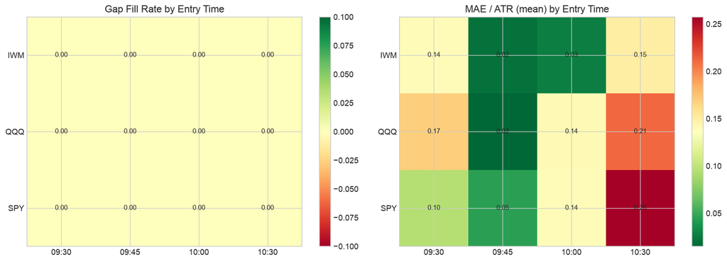

```python
# Heat map: fill rate × entry_time × ticker
fig, axes = plt.subplots(1, 2, figsize=(14, 5))

for ax, metric, label in [
    (axes[0], "gap_filled", "Gap Fill Rate"),
    (axes[1], "mae_pct_atr", "MAE / ATR (mean)"),
]:
    pivot = all_paths.groupby(["ticker", "entry_time"])[metric].mean().unstack()
    pivot = pivot[ENTRY_TIMES]  # ensure consistent column order
    im = ax.imshow(pivot.values.astype(float), aspect="auto", cmap="RdYlGn" if "fill" in metric else "RdYlGn_r")
    ax.set_xticks(range(len(ENTRY_TIMES)))
    ax.set_xticklabels(ENTRY_TIMES)
    ax.set_yticks(range(len(pivot.index)))
    ax.set_yticklabels(pivot.index)
    ax.set_title(f"{label} by Entry Time")
    plt.colorbar(im, ax=ax)
    for i in range(len(pivot.index)):
        for j in range(len(ENTRY_TIMES)):
            ax.text(j, i, f"{pivot.values[i, j]:.2f}", ha="center", va="center", fontsize=9)

plt.tight_layout()
plt.savefig(CHARTS_DIR / "05_entry_timing_grid.png", dpi=150, bbox_inches="tight")
plt.show()
```

### 3d. Pre-market Fill % as Predictor

Does a gap that's already partially filling in pre-market revert faster/more reliably?

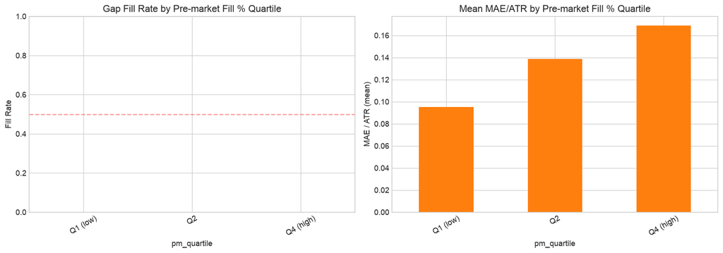

```python
open_paths_pm = open_paths.dropna(subset=["premarket_fill_pct"])
open_paths_pm = open_paths_pm.copy()
open_paths_pm["pm_quartile"] = pd.qcut(
    open_paths_pm["premarket_fill_pct"], q=4,
    labels=["Q1 (low)", "Q2", "Q3", "Q4 (high)"]
)

fig, axes = plt.subplots(1, 2, figsize=(14, 5))

# Fill rate by quartile
fill_by_q = open_paths_pm.groupby("pm_quartile", observed=True)["gap_filled"].mean()
fill_by_q.plot(kind="bar", ax=axes[0], color="#1f77b4", rot=30)
axes[0].set_title("Gap Fill Rate by Pre-market Fill % Quartile")
axes[0].set_ylabel("Fill Rate")
axes[0].set_ylim(0, 1)
axes[0].axhline(0.5, color="red", linestyle="--", alpha=0.4)

# MAE by quartile
mae_by_q = open_paths_pm.groupby("pm_quartile", observed=True)["mae_pct_atr"].mean()
mae_by_q.plot(kind="bar", ax=axes[1], color="#ff7f0e", rot=30)
axes[1].set_title("Mean MAE/ATR by Pre-market Fill % Quartile")
axes[1].set_ylabel("MAE / ATR (mean)")

plt.tight_layout()
plt.savefig(CHARTS_DIR / "06_premarket_predictor.png", dpi=150, bbox_inches="tight")
plt.show()
```

### 3e. VIX Regime Breakdown

```
Price-path metrics by VIX regime:
```

| vix_regime | direction | n_events | fill_rate | mae_mean | mae_p90 |
| --- | --- | --- | --- | --- | --- |
| mid | gap_up | 3 | 0.0 | 0.134 | 0.163 |

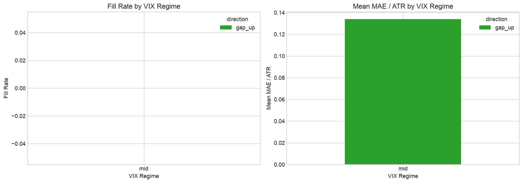

```python
regime_summary = open_paths.groupby(["vix_regime", "direction"]).agg(
    n_events=("gap_filled", "count"),
    fill_rate=("gap_filled", "mean"),
    mae_mean=("mae_pct_atr", "mean"),
    mae_p90=("mae_pct_atr", lambda x: x.quantile(0.90)),
).round(3)
print("Price-path metrics by VIX regime:")
display(regime_summary)

fig, axes = plt.subplots(1, 2, figsize=(14, 5))
for ax, metric, label in [
    (axes[0], "fill_rate", "Fill Rate"),
    (axes[1], "mae_mean", "Mean MAE / ATR"),
]:
    pivot = regime_summary[metric].unstack()
    pivot.plot(kind="bar", ax=ax,
               color=[COLORS_DIR.get(c, "gray") for c in pivot.columns], rot=0)
    ax.set_title(f"{label} by VIX Regime")
    ax.set_xlabel("VIX Regime")
    ax.set_ylabel(label)

plt.tight_layout()
plt.savefig(CHARTS_DIR / "07_vix_regime.png", dpi=150, bbox_inches="tight")
plt.show()
```

## 4. Credit Spread Simulation — Layer 2 [Synthetic]

> ⚠️ **All P&L values in this section are SYNTHETIC.** Spreads are priced using Black-Scholes with VIX/100 as annualized IV proxy. There is no real options chain data — actual market prices will differ due to IV smile, bid/ask spread, liquidity, and early assignment risk.

For each gap event and entry time we:

1. Price a 1-DTE credit spread anchored at prev_close (width = 0.5 × ATR).
2. Simulate 7 exit strategies: EOD, PT25/50/75 (profit targets), SL1×/2×/3× (stop-loss).
3. Compute win rate, expectancy, and profit factor per combination.

```python
print("Simulating credit spreads...")
exits = simulate_exits(
    all_paths,
    profit_targets=PROFIT_TARGETS,
    stop_multiples=STOP_MULTIPLES,
)
print(f"Exit rows: {len(exits):,}  ({len(all_paths):,} path rows × 7 exit strategies)")
spy_exits = exits[exits["ticker"] == "SPY"]
if len(spy_exits) > 0:
    print(f"Sample credit (SPY, first event): ${spy_exits['credit'].iloc[0]:.4f}")
```

```
Simulating credit spreads...
Exit rows: 84  (12 path rows × 7 exit strategies)
Sample credit (SPY, first event): $0.0481
```

### 4a. Spread Pricing at Each Entry Time

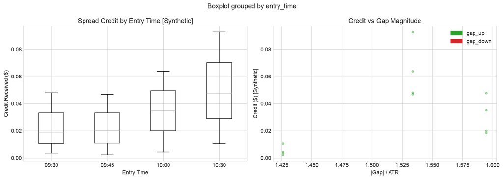

```python
eod_exits = exits[exits["exit_strategy"] == "EOD"]

fig, axes = plt.subplots(1, 2, figsize=(14, 5))

# Credit distribution by entry time
eod_exits.boxplot(column="credit", by="entry_time", ax=axes[0])
axes[0].set_title("Spread Credit by Entry Time [Synthetic]")
axes[0].set_xlabel("Entry Time")
axes[0].set_ylabel("Credit Received ($)")
plt.sca(axes[0])
plt.title("Spread Credit by Entry Time [Synthetic]")

# Credit vs gap_ratio scatter
axes[1].scatter(
    eod_exits["gap_ratio"].abs(), eod_exits["credit"],
    c=[COLORS_DIR.get(d, "gray") for d in eod_exits["direction"]],
    alpha=0.4, s=15,
)
axes[1].set_xlabel("|Gap| / ATR")
axes[1].set_ylabel("Credit ($) [Synthetic]")
axes[1].set_title("Credit vs Gap Magnitude")
from matplotlib.patches import Patch
axes[1].legend(handles=[
    Patch(color=COLORS_DIR["gap_up"], label="gap_up"),
    Patch(color=COLORS_DIR["gap_down"], label="gap_down"),
])

plt.tight_layout()
plt.savefig(CHARTS_DIR / "08_spread_pricing.png", dpi=150, bbox_inches="tight")
plt.show()
```

### 4b. Exit Strategy Comparison

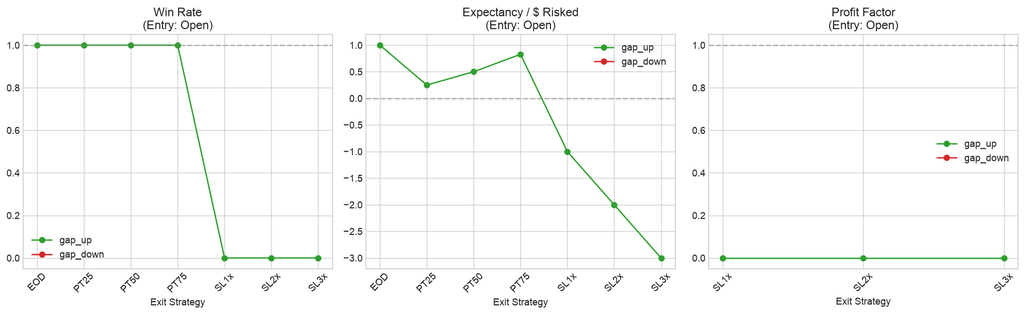

```python
metrics = compute_metrics(exits)

# Focus on open entry for clarity
metrics_open = metrics[metrics["entry_time"] == "09:30"].copy()

fig, axes = plt.subplots(1, 3, figsize=(16, 5))

EXIT_ORDER = ["EOD", "PT25", "PT50", "PT75", "SL1x", "SL2x", "SL3x"]

for direction in ["gap_up", "gap_down"]:
    m = metrics_open[metrics_open["direction"] == direction].set_index("exit_strategy")
    m = m.reindex(EXIT_ORDER).dropna()

    for ax, col, label in [
        (axes[0], "win_rate", "Win Rate"),
        (axes[1], "expectancy_per_dollar", "Expectancy / $1 Risked [Synthetic]"),
        (axes[2], "profit_factor", "Profit Factor [Synthetic]"),
    ]:
        ax.plot(
            m.index, m[col],
            marker="o", label=direction, color=COLORS_DIR[direction]
        )

for ax, title in zip(axes, ["Win Rate", "Expectancy / $ Risked", "Profit Factor"]):
    ax.set_title(f"{title}\n(Entry: Open)")
    ax.set_xlabel("Exit Strategy")
    ax.tick_params(axis="x", rotation=45)
    ax.legend()
    ax.axhline(0 if "Expectancy" in title else 1, color="gray", linestyle="--", alpha=0.5)

plt.tight_layout()
plt.savefig(CHARTS_DIR / "09_exit_comparison.png", dpi=150, bbox_inches="tight")
plt.show()
```

### 4c. Expectancy by Exit × Entry Time

```python
# Summary table: expectancy_per_dollar for all exit × entry_time combinations
pivot_exp = metrics[metrics["direction"] == "gap_up"].pivot_table(
    index="exit_strategy", columns="entry_time", values="expectancy_per_dollar"
)
pivot_exp = pivot_exp.reindex(EXIT_ORDER).reindex(columns=ENTRY_TIMES)

print("[Synthetic] Gap Up — Expectancy per $1 Risked:")
display(pivot_exp.round(3).style.background_gradient(cmap="RdYlGn", axis=None))

pivot_exp_dn = metrics[metrics["direction"] == "gap_down"].pivot_table(
    index="exit_strategy", columns="entry_time", values="expectancy_per_dollar"
)
pivot_exp_dn = pivot_exp_dn.reindex(EXIT_ORDER).reindex(columns=ENTRY_TIMES)

print("\n[Synthetic] Gap Down — Expectancy per $1 Risked:")
display(pivot_exp_dn.round(3).style.background_gradient(cmap="RdYlGn", axis=None))
```

```
[Synthetic] Gap Up — Expectancy per $1 Risked:
```

| entry_time exit_strategy | 09:30 | 09:45 | 10:00 | 10:30 |
| --- | --- | --- | --- | --- |
| EOD | 1.000000 | 1.000000 | 1.000000 | 1.000000 |
| PT25 | 0.250000 | 0.250000 | 0.250000 | 0.250000 |
| PT50 | 0.500000 | 0.500000 | 0.500000 | 0.807000 |
| PT75 | 0.828000 | 0.750000 | 0.989000 | 1.000000 |
| SL1x | -1.000000 | -1.000000 | -1.000000 | -1.000000 |
| SL2x | -2.000000 | -2.000000 | -2.000000 | -2.000000 |
| SL3x | -3.000000 | -3.000000 | -3.000000 | -3.000000 |

```
[Synthetic] Gap Down — Expectancy per $1 Risked:
```

| entry_time exit_strategy | 09:30 | 09:45 | 10:00 | 10:30 |
| --- | --- | --- | --- | --- |
| EOD | nan | nan | nan | nan |
| PT25 | nan | nan | nan | nan |
| PT50 | nan | nan | nan | nan |
| PT75 | nan | nan | nan | nan |
| SL1x | nan | nan | nan | nan |
| SL2x | nan | nan | nan | nan |
| SL3x | nan | nan | nan | nan |

### 4d. Tail Risk — MAE Distribution and Worst Cases

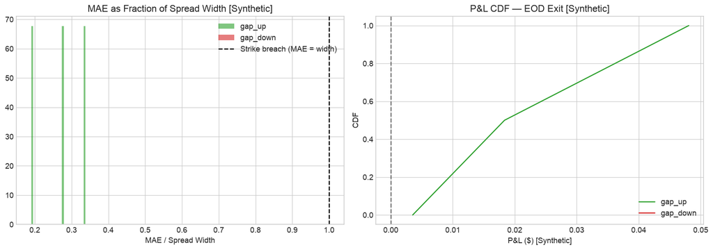

```
Five worst EOD outcomes [Synthetic]:
```

|  | date | ticker | direction | mae | pnl | gap_ratio |
| --- | --- | --- | --- | --- | --- | --- |
| 56 | 2026-04-08 | IWM | gap_up | 0.835 | 0.0035 | 1.4262 |
| 28 | 2026-04-08 | QQQ | gap_up | 2.130 | 0.0183 | 1.5949 |
| 0 | 2026-04-08 | SPY | gap_up | 1.061 | 0.0481 | 1.5337 |

```python
fig, axes = plt.subplots(1, 2, figsize=(14, 5))

# MAE distribution vs spread width
eod_exits_open = eod_exits[eod_exits["entry_time"] == "09:30"].copy()
eod_exits_open["mae_as_pct_width"] = eod_exits_open["mae"] / eod_exits_open["spread_width"]

for direction, color in COLORS_DIR.items():
    subset = eod_exits_open[eod_exits_open["direction"] == direction]["mae_as_pct_width"]
    axes[0].hist(subset, bins=30, alpha=0.6, color=color, label=direction, density=True)
axes[0].axvline(1.0, color="black", linestyle="--", label="Strike breach (MAE = width)")
axes[0].set_xlabel("MAE / Spread Width")
axes[0].set_title("MAE as Fraction of Spread Width [Synthetic]")
axes[0].legend()

# Tail loss CDF
for direction, color in COLORS_DIR.items():
    subset = eod_exits_open[eod_exits_open["direction"] == direction]["pnl"].sort_values()
    axes[1].plot(subset.values, np.linspace(0, 1, len(subset)), color=color, label=direction)
axes[1].axvline(0, color="black", linestyle="--", alpha=0.5)
axes[1].set_xlabel("P&L ($) [Synthetic]")
axes[1].set_ylabel("CDF")
axes[1].set_title("P&L CDF — EOD Exit [Synthetic]")
axes[1].legend()

plt.tight_layout()
plt.savefig(CHARTS_DIR / "10_tail_risk.png", dpi=150, bbox_inches="tight")
plt.show()

worst = eod_exits_open.nsmallest(5, "pnl")[["date", "ticker", "direction", "mae", "pnl", "gap_ratio"]]
print("\nFive worst EOD outcomes [Synthetic]:")
display(worst.round(4))
```

## 5. Multi-Asset Comparison

SPY, QQQ, IWM are the primary assets. ES=F and NQ=F are included as secondary (note: continuous contract roll gaps may inflate event counts for futures).

```
Fill rate and MAE by ticker (entry: open):
```

| ticker | n_events | fill_rate | mae_mean | mae_p90 |
| --- | --- | --- | --- | --- |
| IWM | 1 | 0.0 | 0.139 | 0.139 |
| QQQ | 1 | 0.0 | 0.169 | 0.169 |
| SPY | 1 | 0.0 | 0.095 | 0.095 |

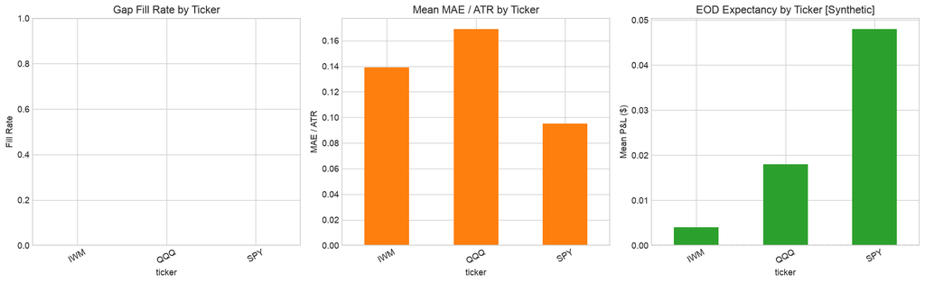

```python
open_paths_all = all_paths[all_paths["entry_time"] == "09:30"]
metrics_open_all = metrics[metrics["entry_time"] == "09:30"]

# Fill rate and MAE by ticker
fill_mae = open_paths_all.groupby("ticker").agg(
    n_events=("gap_filled", "count"),
    fill_rate=("gap_filled", "mean"),
    mae_mean=("mae_pct_atr", "mean"),
    mae_p90=("mae_pct_atr", lambda x: x.quantile(0.90)),
).round(3)
print("Fill rate and MAE by ticker (entry: open):")
display(fill_mae)

fig, axes = plt.subplots(1, 3, figsize=(16, 5))

fill_mae["fill_rate"].plot(kind="bar", ax=axes[0], color="#1f77b4", rot=30)
axes[0].set_title("Gap Fill Rate by Ticker")
axes[0].set_ylabel("Fill Rate")
axes[0].set_ylim(0, 1)

fill_mae["mae_mean"].plot(kind="bar", ax=axes[1], color="#ff7f0e", rot=30)
axes[1].set_title("Mean MAE / ATR by Ticker")
axes[1].set_ylabel("MAE / ATR")

# Expectancy EOD by ticker [Synthetic]
eod_metrics_by_ticker = exits[
    (exits["exit_strategy"] == "EOD") & (exits["entry_time"] == "09:30")
].groupby("ticker").agg(
    expectancy=("pnl", "mean"),
    win_rate=("win", "mean"),
).round(3)
eod_metrics_by_ticker["expectancy"].plot(kind="bar", ax=axes[2], color="#2ca02c", rot=30)
axes[2].set_title("EOD Expectancy by Ticker [Synthetic]")
axes[2].set_ylabel("Mean P&L ($)")
axes[2].axhline(0, color="black", linestyle="--", alpha=0.5)

plt.tight_layout()
plt.savefig(CHARTS_DIR / "11_multi_asset.png", dpi=150, bbox_inches="tight")
plt.show()
```

## 6. Key Findings & Limitations

### Swing Trainer Integration Map

When this research confirms edge worth trading, the `lib/` modules port directly:

| Research | Swing Trainer |
| --- | --- |
| `lib/data.py` | `backend/services/data.py` (extend existing yfinance provider) |
| `lib/events.py` | `backend/services/gap_events.py` (new service) |
| `lib/path.py` | `backend/services/gap_path.py` (new service) |
| `lib/spreads.py` | `backend/services/options.py` (extend `YFinanceOptionsProvider`) |

**Suggested integration phase:** `GET /api/gaps/events` returns today's qualifying gaps, `GET /api/gaps/analysis` returns metrics for the chosen ticker. New "Gap Scanner" tab in the Bull Assistant UI.